# Assignment1

## get samples that have counts data

```r
rs <- dbGetQuery(con,sql)
counts_files <- rs$supplementary_file[grep(rs$supplementary_file,pattern = "count",ignore.case = TRUE)]
```

```r
rs
```

| title | gse | title | submission_date | supplementary_file |
| --- | --- | --- | --- | --- |
| Gene expression analyses of hematopoietic stem and progenitor cells treated with extracellular vesicles isolated from adult and fetal MSCs | GSE165921 | Illumina NovaSeq 6000 (Homo sapiens) | 2021-02-01 | ftp://ftp.ncbi.nlm.nih.gov/geo/series/GSE165nnn/GSE165921/suppl/GSE165921_RAW.tar |
| Tumor-associated hematopoietic stem and progenitor cells positively linked to glioblastoma progression | GSE165238 | Illumina NovaSeq 6000 (Homo sapiens) | 2021-01-21 | ftp://ftp.ncbi.nlm.nih.gov/geo/series/GSE165nnn/GSE165238/suppl/GSE165238_Igor1-2-4_filtered_feature_bc_matrix.csv.gz |
| Minor intron retention drives clonal hematopoietic disorders and diverse cancer predisposition. | GSE162136 | Illumina HiSeq 4000 (Homo sapiens) | 2020-11-25 | NA |
| A surge of DNA damage links transcriptional reprogramming and hematopoietic deficit in Fanconi anemia | GSE161891 | Illumina HiSeq 2000 (Homo sapiens) | 2020-11-20 | NA |
| Profiling the blood compartment of Hematopoietic Stem Cell Transplant patients during Human Cytomegalovirus reactivation | GSE161752 | Illumina NextSeq 500 (Homo sapiens) | 2020-11-18 | ftp://ftp.ncbi.nlm.nih.gov/geo/series/GSE161nnn/GSE161752/suppl/GSE161752_hff.txt.gz;\tftp://ftp.ncbi.nlm.nih.gov/geo/series/GSE161nnn/GSE161752/suppl/GSE161752_patients.txt.gz;\tftp://ftp.ncbi.nlm.ni… |
| Profiling the blood compartment of Hematopoietic Stem Cell Transplant patients during Human Cytomegalovirus reactivation | GSE161752 | Illumina NovaSeq 6000 (Homo sapiens) | 2020-11-18 | ftp://ftp.ncbi.nlm.nih.gov/geo/series/GSE161nnn/GSE161752/suppl/GSE161752_hff.txt.gz;\tftp://ftp.ncbi.nlm.nih.gov/geo/series/GSE161nnn/GSE161752/suppl/GSE161752_patients.txt.gz;\tftp://ftp.ncbi.nlm.ni… |
| Total RNA sequencing of KIR+ and KIR- NK cells from patients experiencing or not a Cytomegalovirus reactivation after haploidentical hematopoietic stem cell transplantation | GSE160362 | Illumina NextSeq 500 (Homo sapiens) | 2020-10-28 | ftp://ftp.ncbi.nlm.nih.gov/geo/series/GSE160nnn/GSE160362/suppl/GSE160362_Counts_table.csv.gz |
| Transcriptional and protein-level profiling of engraftable human fetal liver (fl)-derived hematopoietic stem cells (HSCS) | GSE160251 | Illumina NextSeq 500 (Homo sapiens) | 2020-10-27 | ftp://ftp.ncbi.nlm.nih.gov/geo/series/GSE160nnn/GSE160251/suppl/GSE160251_sc.definitive.Rds.gz |
| Recapitulative hematopoietic development of human pluripotent stem cells in the absence of exogenous cytokines | GSE159672 | Illumina HiSeq 2500 (Homo sapiens) | 2020-10-20 | ftp://ftp.ncbi.nlm.nih.gov/geo/series/GSE159nnn/GSE159672/suppl/GSE159672_genes_cpm_expression.tsv.gz |
| Recapitulative hematopoietic development of human pluripotent stem cells in the absence of exogenous cytokines | GSE159672 | HiSeq X Ten (Homo sapiens) | 2020-10-20 | ftp://ftp.ncbi.nlm.nih.gov/geo/series/GSE159nnn/GSE159672/suppl/GSE159672_genes_cpm_expression.tsv.gz |

[output cut: 214 more lines]

## Data exploration:

Get GEO description of dataset: which is GSE160499,the title of the dataset is Nrf2 overexpression increases risk of high tumor mutation burden in acute myeloid leukemia.

```r
gse <- GEOquery::getGEO("GSE160499",GSEMatrix=FALSE)
```

```
Using locally cached version of GSE160499 found here:
C:\Users\cindy\AppData\Local\Temp\RtmpmoUDlW/GSE160499.soft.gz
Reading file....
Parsing....
Found 8 entities...
GPL20795 (1 of 9 entities)
GSM4874215 (2 of 9 entities)
GSM4874216 (3 of 9 entities)
GSM4874217 (4 of 9 entities)
GSM4874218 (5 of 9 entities)
GSM4874219 (6 of 9 entities)
GSM4874220 (7 of 9 entities)
GSM4874221 (8 of 9 entities)
```

```r
knitr::kable(data.frame(head(GEOquery::Meta(gse))), format = "html")
```

| contact_address | contact_city | contact_country | contact_email | contact_institute | contact_name |
| --- | --- | --- | --- | --- | --- |
| 28 Guiyi Street, Yunyan District | Guiyang | China | pingliu2017@126.com | Affiliated Hospital of Guizhou Medical University | Ping,,Liu |

Information about platform:

```r
current_gpl <- names(GPLList(gse))[1]
current_gpl_info <- Meta(getGEO(current_gpl))
```

```
File stored at:
C:\Users\cindy\AppData\Local\Temp\Rtmp6Dbq4W/GPL20795.soft
```

```r
current_gpl_info$title
```

```
[1] "HiSeq X Ten (Homo sapiens)"
```

```r
current_gpl_info$last_update_date
```

```
[1] "Mar 20 2019"
```

```r
current_gpl_info$organism
```

```
[1] "Homo sapiens"
```

## Load the expression data

```r
sfiles = GEOquery::getGEOSuppFiles('GSE160499')
fnames = rownames(sfiles)
# there is only one supplemental file
Nrf2_exp = read.delim(fnames[1],header=TRUE,
                check.names = FALSE)
```

```r
knitr::kable(Nrf2_exp[5:10,1:8], format = "html")
```

[output not shown]

# 3-Cleaning the data

How many genes do we have measurements for?

```r
dim(Nrf2_exp)
```

[output not shown]

## DefineGroups

Since the experiment divided AML patients into 2 groups either expressing high or low levels of Nrf2.I classified patients into 2 groups:L represent low expression and H represent high expression.

```r
#Extract patient information
Patient <- colnames(Nrf2_exp)[2:8]
#extract type of patient cell,L stand for the patient that expresse low level of Nrf2 and H represent patients with high level of Nrf2
CellTypes<-c("L","L","L","H","H","H","H")
df <- data.frame(Patient,CellTypes)
```

## Are any of genes duplicated?

There is no gene duplicated

```r
summarized_gene_counts <- sort(table(Nrf2_exp$AccID),
                               decreasing = TRUE)
knitr::kable(table(Nrf2_exp$AccID)[5:8], format="html")
```

| Var1 | Freq |
| --- | --- |
| 5-HT3C2 | 1 |
| A1BG | 1 |
| A1BG-AS1 | 1 |
| A1CF | 1 |

Filter weakly expressed and noninformative (e.g.,non-aligned) features. In edgeR, it is recommended to remove features without at least 1 read per million in n of the samples, where n is the size of the smallest group of replicates. For this dataset - the smallest group of replicates is patients with low Nrf2 expression with sample size 3

```r
#translate out counts into counts per million using
#the edgeR package function cpm
cpms = edgeR::cpm(Nrf2_exp[,2:8])
rownames(cpms) <- Nrf2_exp[,1]
# get rid of low counts
keep = rowSums(cpms >1) >=3
Nrf2_exp_filtered = Nrf2_exp[keep,]
```

It filtered out the noninformative features and the size of data set is much smaller right now

```r
dim(Nrf2_exp_filtered)
```

```
[1] 14652     8
```

```r
dim(Nrf2_exp)
```

```
[1] 54261     8
```

# 4-Normalization:

## Distribution of our data-Boxplot

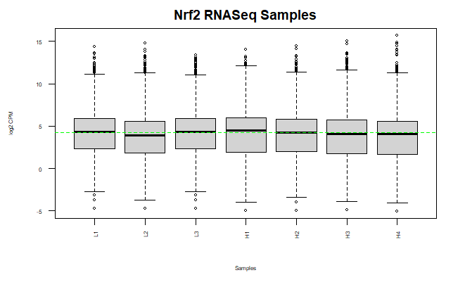

```r
data2plot <- log2(edgeR::cpm(Nrf2_exp_filtered[,2:8]))
boxplot(data2plot, xlab = "Samples", ylab = "log2 CPM",
        las = 2, cex = 0.5, cex.lab = 0.5,
        cex.axis = 0.5, main = "Nrf2 RNASeq Samples")
#draw the median on each box plot
abline(h = median(apply(data2plot, 2, median)),
       col = "green", lwd = 0.6, lty = "dashed")
```

## Distribution of our data-Density plot

```r
counts_density <- apply(log2(edgeR::cpm(Nrf2_exp_filtered[,2:8])),
                        2, density)
  #calculate the limits across all the samples
    xlim <- 0; ylim <- 0
    for (i in 1:length(counts_density)) {
      xlim <- range(c(xlim, counts_density[[i]]$x));
      ylim <- range(c(ylim, counts_density[[i]]$y))
    }
    cols <- rainbow(length(counts_density))
    ltys <- rep(1, length(counts_density))
    #plot the first density plot to initialize the plot
    plot(counts_density[[1]], xlim=xlim, ylim=ylim, type="n",
         ylab="Smoothing density of log2-CPM",
         main="", cex.lab = 0.85)
    #plot each line
    for (i in 1:length(counts_density))
      lines(counts_density[[i]], col=cols[i], lty=ltys[i])
```

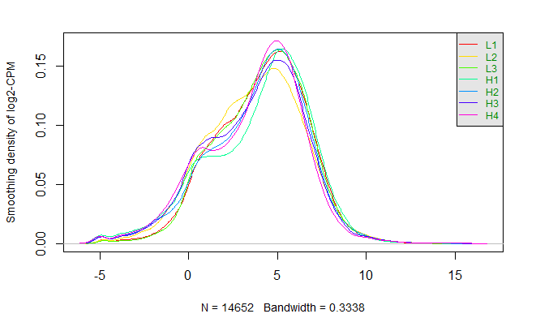

```r
    #create legend
    legend("topright", colnames(data2plot),
           col=cols, lty=ltys, cex=0.75,
           border ="blue",  text.col = "green4",
           merge = TRUE, bg = "gray90")
```

## MA plot for Nrf2 data-comparing the L1 and H1 sample in data set

```r
edgeR::plotMA(log2(Nrf2_exp[,c(2,5)]), ylab="M - ratio log expression",
       main="Nrf2 L1 vs Nrf2 H1 example")
```

[output not shown]

## Applying TMM to our dataset

create an edgeR container for RNASeq count data

```r
celltypes <-colnames(Nrf2_exp)[2:8]
filtered_data_matrix <- as.matrix(Nrf2_exp_filtered[,2:8])
rownames(filtered_data_matrix) <- Nrf2_exp_filtered$AccID
d = edgeR::DGEList(counts=filtered_data_matrix, group=df$CellTypes)
```

## Calculate the normalization factors

```r
d = edgeR::calcNormFactors(d)
```

## Get normalized data

```r
#get the normalized data
normalized_counts <- edgeR::cpm(d)
```

```r
normalized_counts
```

[output not shown]

[output cut: 232 more lines]

[output not shown]

## Inspect the sample separation using a multidimensional scaling plot or MDS plot post normalization.

```r
edgeR::plotMDS(d, labels=celltypes,
  col = c("darkgreen","blue")[factor(df$CellTypes)])
```

[output not shown]

# 5-Dispersion

```r
model_design <- model.matrix(~df$Patient
                             + df$CellTypes+0)
d <- edgeR::estimateDisp(d, model_design)
```

```
No residual df: setting dispersion to NA
```

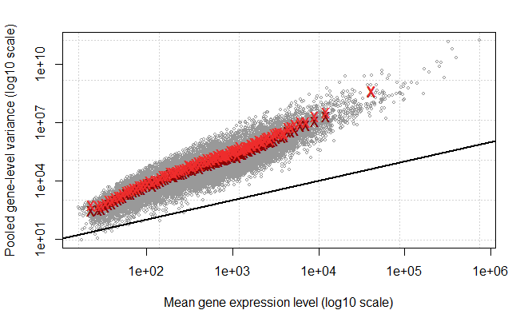

```r
edgeR::plotMeanVar(d, show.raw.vars = TRUE, show.tagwise.vars=TRUE,
            show.ave.raw.vars = TRUE,
            NBline=TRUE,
            show.binned.common.disp.vars = TRUE)
```

# 6-Identifier mapping

```r
#install biomart package
library(biomaRt)
#Get all availale marts
listMarts()
```

| biomart | version |
| --- | --- |
| ENSEMBL_MART_ENSEMBL | Ensembl Genes 105 |
| ENSEMBL_MART_MOUSE | Mouse strains 105 |
| ENSEMBL_MART_SNP | Ensembl Variation 105 |
| ENSEMBL_MART_FUNCGEN | Ensembl Regulation 105 |

```r
#If different version is needed
listEnsemblArchives()[1:10,]
```

|  | name | date | url | version | current_release |
| --- | --- | --- | --- | --- | --- |
| 1 | Ensembl GRCh37 | Feb 2014 | https://grch37.ensembl.org | GRCh37 |  |
| 2 | Ensembl 105 | Dec 2021 | https://dec2021.archive.ensembl.org | 105 | * |
| 3 | Ensembl 104 | May 2021 | https://may2021.archive.ensembl.org | 104 |  |
| 4 | Ensembl 103 | Feb 2021 | https://feb2021.archive.ensembl.org | 103 |  |
| 5 | Ensembl 102 | Nov 2020 | https://nov2020.archive.ensembl.org | 102 |  |
| 6 | Ensembl 101 | Aug 2020 | https://aug2020.archive.ensembl.org | 101 |  |
| 7 | Ensembl 100 | Apr 2020 | https://apr2020.archive.ensembl.org | 100 |  |
| 8 | Ensembl 99 | Jan 2020 | https://jan2020.archive.ensembl.org | 99 |  |
| 9 | Ensembl 98 | Sep 2019 | https://sep2019.archive.ensembl.org | 98 |  |
| 10 | Ensembl 97 | Jul 2019 | https://jul2019.archive.ensembl.org | 97 |  |

```r
#Connect to the desired mart
ensembl <- useMart("ensembl")
```

```r
#Get the set of datasets available
datasets <- listDatasets(ensembl)
knitr::kable(head(datasets),format = "html")
```

```r
#Limit to the human datasets available
knitr::kable(head(datasets[grep(datasets$dataset,
                  pattern = "sapiens"),]),format = "html")
```

|  | dataset | description | version |
| --- | --- | --- | --- |
| 80 | hsapiens_gene_ensembl | Human genes (GRCh38.p13) | GRCh38.p13 |

```r
ensembl = useDataset("hsapiens_gene_ensembl",mart=ensembl)
```

## Building a Biomart Query

We are trying to convert Human Ensembl Gene Ids to HGNC symbols

```r
#how many filters are there?
dim(listFilters(ensembl))
```

```
[1] 439   2
```

```r
knitr::kable(listFilters(ensembl)[1:10,1:2], type="html")
```

| name | description |
| --- | --- |
| chromosome_name | Chromosome/scaffold name |
| start | Start |
| end | End |
| strand | Strand |
| chromosomal_region | e.g. 1:100:10000:-1, 1:100000:200000:1 |
| with_biogrid | With BioGRID Interaction data, The General Repository for Interaction Datasets ID(s) |
| with_ccds | With CCDS ID(s) |
| with_chembl | With ChEMBL ID(s) |
| with_dbass3 | With DataBase of Aberrant 3’ Splice Sites ID(s) |
| with_dbass5 | With DataBase of Aberrant 5’ Splice Sites ID(s) |

```r
biomart_human_filters <- listFilters(ensembl)
knitr::kable(biomart_human_filters[
  grep(biomart_human_filters$name,pattern="ensembl"),],
      format="html")
```

|  | name | description |
| --- | --- | --- |
| 51 | ensembl_gene_id | Gene stable ID(s) [e.g. ENSG00000000003] |
| 52 | ensembl_gene_id_version | Gene stable ID(s) with version [e.g. ENSG00000000003.15] |
| 53 | ensembl_transcript_id | Transcript stable ID(s) [e.g. ENST00000000233] |
| 54 | ensembl_transcript_id_version | Transcript stable ID(s) with version [e.g. ENST00000000233.10] |
| 55 | ensembl_peptide_id | Protein stable ID(s) [e.g. ENSP00000000233] |
| 56 | ensembl_peptide_id_version | Protein stable ID(s) with version [e.g. ENSP00000000233.5] |
| 57 | ensembl_exon_id | Exon ID(s) [e.g. ENSE00000000003] |

## Attributes

```r
knitr::kable(listAttributes(ensembl)[1:10,1:2], type="html")
```

| name | description |
| --- | --- |
| ensembl_gene_id | Gene stable ID |
| ensembl_gene_id_version | Gene stable ID version |
| ensembl_transcript_id | Transcript stable ID |
| ensembl_transcript_id_version | Transcript stable ID version |
| ensembl_peptide_id | Protein stable ID |
| ensembl_peptide_id_version | Protein stable ID version |
| ensembl_exon_id | Exon stable ID |
| description | Gene description |
| chromosome_name | Chromosome/scaffold name |
| start_position | Gene start (bp) |

```r
conversion_stash <- "Nrf2_id_conversion.rds"
if(file.exists(conversion_stash)){
  Nrf2_id_conversion <- readRDS(conversion_stash)
  print("yes")
} else {
  Nrf2_id_conversion <- getBM(attributes = c("ensembl_gene_id","hgnc_symbol"),
                            filters = c("hgnc_symbol"),
                            values = Nrf2_exp_filtered$AccID,
                            mart = ensembl)
  saveRDS(Nrf2_id_conversion, conversion_stash)
}
```

```r
 length(which(rownames(normalized_counts) %in%
                Nrf2_id_conversion$hgnc_symbol))
```

```
[1] 12740
```

```r
nrow(normalized_counts)
```

```r
nrow(normalized_counts)-nrow(Nrf2_id_conversion)
```

```r
normalized_counts_annot <- merge(Nrf2_id_conversion,normalized_counts,by.x=1,by.y=0,all.y=TRUE)
knitr::kable(normalized_counts_annot[1:5,1:5],type = "html")
```

| ensembl_gene_id | hgnc_symbol | L1 | L2 | L3 |
| --- | --- | --- | --- | --- |
| A1BG | NA | 5.693117 | 18.8430707 | 7.461972 |
| A1BG-AS1 | NA | 4.692508 | 6.2086615 | 6.430363 |
| A2M | NA | 3.346863 | 0.1736689 | 6.189654 |
| A2M-AS1 | NA | 1.897706 | 0.0868344 | 2.441475 |
| A4GALT | NA | 1.380150 | 4.9061451 | 6.224042 |

```r
hgnc_symbol_missing_gene <-normalized_counts_annot$hgnc_symbol[which(is.na(normalized_counts_annot$ensembl_gene_id))]

length(hgnc_symbol_missing_gene)
```

```
[1] 0
```

# 7-Interpret, and document

This dataset talks about Nuclear factor erythroid 2-related factor 2 (Nrf2) plays an important role in chemoresistance.High Nrf2 expression significantly inhibit DNA. mismtach repair pathways(MMR)

### What are the control and test conditions of the dataset?

The test contition for this dataset is compare human Nrf2 overexpresion clone. Cells are transfect with high Nrf2 expression and low Nrf2 expression.The control is cells transfected with hempty vector(EV).In this experiment,we are studying the role of Nrf2 played in AML patients.The results had indicates that patients with higher Nrf2 expression had a higher frequency of gene mutation and drug resistance.

### Why is the dataset of interest to you?

I found this dataset interesting because Acute myeloid leukemia(AML) is a malignant tumor of myeloid progenitors.Despite the fact that leukemia cells can be killed completely by chemotherapy but the 5 year survival rate is very poor. Majority of AML patient died because of initial resistance to chemotherapy and relapsed AML.Therefore the resistant of leukemia cell to chemotherapy is the major obstacle in the treatment of AML.This dataset illustrate the correaltion between Nrf2 and chemotherapy resistant which indicates that Nfr2 might be a potential target in future AML therapy.

### Were there expression values that were not unique for specific genes? How did you handle these?

There are no duplication of genes in the original file If there are ,we can find the duplicated gene and removed manually

### How did you handle replicates?

# Reference

1.Lecture modules:https://q.utoronto.ca/courses/248455/files/19147947?module_item_id=3463364

2.Liu, P., Ma, D., Wang, P. et al. Nrf2 overexpression increases risk of high tumor mutation burden in acute myeloid leukemia by inhibiting MSH2. Cell Death Dis 12, 20 (2021). https://doi.org/10.1038/s41419-020-03331-x